# Modeling Violent Crime in Philadelphia

Lallen Johnson

2024-01-08

My objective is to model the relationship between and indicator of poverty and violent crime across Philadelphia census tracts. To do this, I’m using the publicly available ProgressPHL [dataset](https://controller.phila.gov/philadelphia-audits/progressphl/#/). The data detail a collection of social, economic, and environmental indicators that fall within three thematic dimensions: Basic Human Needs, Foundations of Wellbeing, and Opportunity.

```r
setwd("C:/Users/johnsonl/OneDrive - american.edu/R/Philadelphia_Violent_Crime")
library(haven)
Philly <-read.csv("progressphl_data_download.csv", header = TRUE)
head(Philly)
```

```
##        geoid neighborhood_name    value average_label rank
## 1 4.2101e+10  Center City East 40.48009 Above Average   27
## 2 4.2101e+10  Center City East 18.21881 Above Average   93
## 3 4.2101e+10  Center City West 42.39852 Above Average   19
## 4 4.2101e+10  Center City West 37.75330 Above Average   36
## 5 4.2101e+10  Center City West 39.38399 Above Average   31
## 6 4.2101e+10  Center City East 24.07153 Above Average   73
##                  variable         region_name         tract_name
## 1 Advanced degree holders Greater Center City Center City East 1
## 2 Advanced degree holders Greater Center City Center City East 2
## 3 Advanced degree holders Greater Center City Center City West 1
## 4 Advanced degree holders Greater Center City Center City West 2
## 5 Advanced degree holders Greater Center City Center City West 3
## 6 Advanced degree holders Greater Center City Center City East 3
```

```r
library(reshape) #Using reshape package to change dataframe from long to wide format
phillyWide <- cast(Philly, geoid + neighborhood_name + region_name + tract_name ~ variable, value = "value")

library(janitor) #Using janitor package to replace spaces w/in variable names w/ underscores
phillyWide <- clean_names(phillyWide)
ls(phillyWide)
```

```
##  [1] "access_to_advanced_education"
##  [2] "access_to_basic_knowledge"
##  [3] "access_to_information_and_communications"
##  [4] "advanced_degree_holders"
##  [5] "alternative_transportation_usage"
##  [6] "associates_degree_holders"
##  [7] "average_commute_time"
##  [8] "bachelors_degree_holders"
##  [9] "basic_human_needs"
## [10] "broadband_subscription_rate"
## [11] "cancer_prevalence"
## [12] "cellular_data_subscription_rate"
## [13] "coronary_heart_disease_prevalence"
## [14] "dental_care_visits"
## [15] "dependency_ratio_65"
```

[output cut: 52 more lines]

```r
library(summarytools)
descr(phillyWide$violent_crime_rate)
```

```
## Descriptive Statistics
## phillyWide$violent_crime_rate
## N: 372
##
##                     violent_crime_rate
## ----------------- --------------------
##              Mean                 9.89
##           Std.Dev                 9.63
##               Min                 0.00
##                Q1                 3.27
##            Median                 6.95
##                Q3                13.55
##               Max                77.12
##               MAD                 6.67
##               IQR                10.25
##                CV                 0.97
##          Skewness                 2.40
##       SE.Skewness                 0.13
##          Kurtosis                 9.43
##           N.Valid               372.00
##         Pct.Valid               100.00
```

```r
library(tidyverse)
```

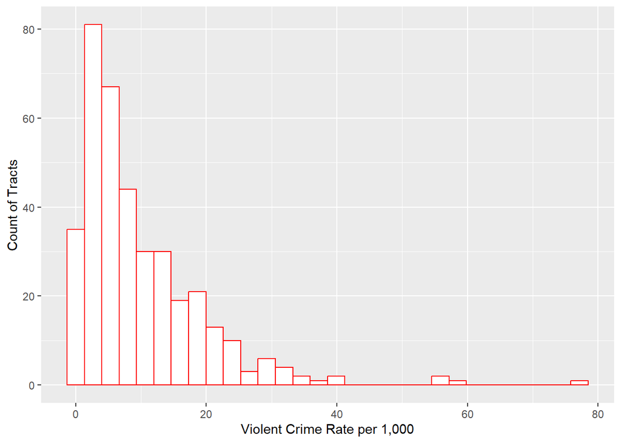

```r
histViol <- ggplot(data=phillyWide, aes(x=violent_crime_rate)) + geom_histogram(color="red", fill="white") + labs(x="Violent Crime Rate per 1,000", y="Count of Tracts")
histViol
```

Violent crime is positively skewed across Philly neighborhoods. That is, there is a small cohort of communities with high levels of reported violence but most communities in the city has substantially less violence. Since my violence measure is a rate (and I do not have access to the raw count data), I’ll create a natural log transformation of violence to generate a more normal distribution.

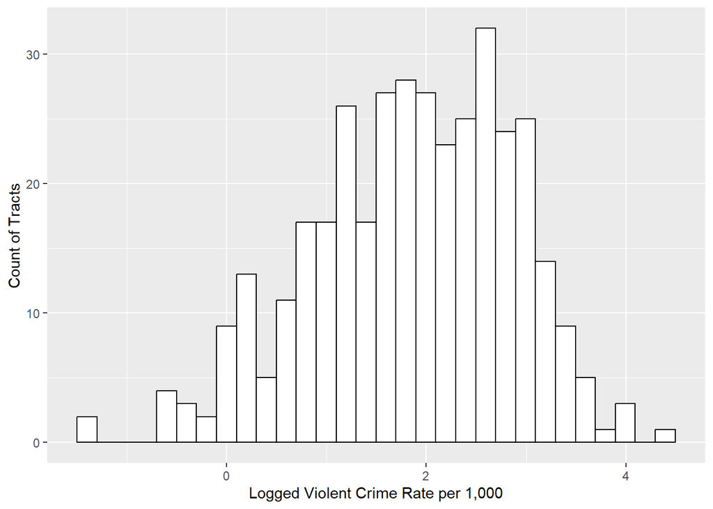

```r
phillyWide$ln_viol_cr <- log(phillyWide$violent_crime_rate)
histln_viol_cr <- ggplot(data=phillyWide, aes(x=ln_viol_cr)) + geom_histogram(color="black", fill="white") + labs(x="Logged Violent Crime Rate per 1,000", y="Count of Tracts")
histln_viol_cr
```

Now, let’s take a look at the food stamp usage measure, which reflect the percent of families in a given tract that reported using food stamps benefits over the past year. I’ll use this as a proxy measure of poverty, since no such measure exists in the ProgressPHL dataset.

```r
descr(phillyWide$food_stamp_usage)
```

```
## Descriptive Statistics
## phillyWide$food_stamp_usage
## N: 372
##
##                     food_stamp_usage
## ----------------- ------------------
##              Mean              26.33
##           Std.Dev              17.37
##               Min               0.00
##                Q1              10.87
##            Median              24.81
##                Q3              39.36
##               Max              72.23
##               MAD              20.98
##               IQR              28.37
##                CV               0.66
##          Skewness               0.40
##       SE.Skewness               0.13
##          Kurtosis              -0.69
##           N.Valid             372.00
##         Pct.Valid             100.00
```

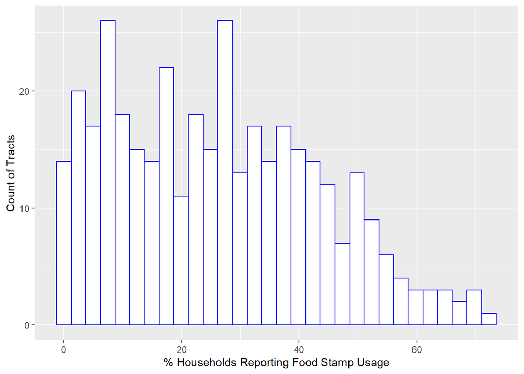

```r
histFoodStamps <- ggplot(data=phillyWide, aes(x=food_stamp_usage)) + geom_histogram(color="blue", fill="white") + labs(x="% Households Reporting Food Stamp Usage", y="Count of Tracts")
histFoodStamps
```

I’m also interested in whether the relationship between tract-level poverty and violence varies, depending on levels of residential isolation. Isolation is an index ranging from 0-1 which reflects the extent to which racial/ethnic minorities are only exposed to one another. Higher values indicate greater isolation. I think that this is important to consider as research has shown how segregation concentrates disadvantage and unsafety for predominately black communities, but affluence and safety for predominately white communities (Peterson & Krivo, 2010).

```r
descr(phillyWide$residential_isolation)
```

```
## Descriptive Statistics
## phillyWide$residential_isolation
## N: 372
##
##                     residential_isolation
## ----------------- -----------------------
##              Mean                    0.64
##           Std.Dev                    0.30
##               Min                    0.05
##                Q1                    0.35
##            Median                    0.70
##                Q3                    0.93
##               Max                    0.99
##               MAD                    0.39
##               IQR                    0.58
##                CV                    0.47
##          Skewness                   -0.35
##       SE.Skewness                    0.13
##          Kurtosis                   -1.33
##           N.Valid                  372.00
##         Pct.Valid                  100.00
```

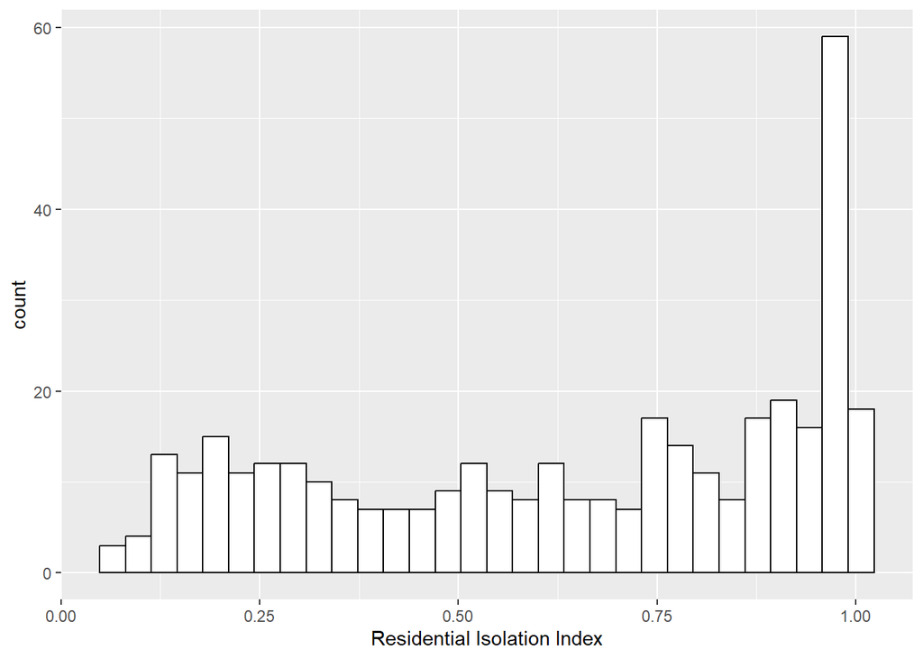

```r
histResIsol <- ggplot(data=phillyWide, aes(x=residential_isolation)) + geom_histogram(color="black", fill="white") + labs(x="Residential Isolation Index")
histResIsol
```

Scatterplots for the poverty -> violence and residential isolation -> violence both indicate positive relationships. In other words, both poor and isolated neighborhoods tend to have higher levels of violent crime.

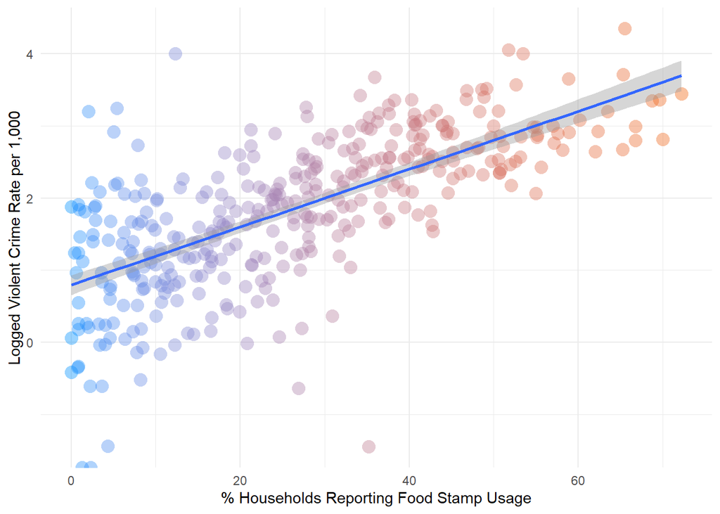

```r
scatterFSV <- ggplot(data = phillyWide, aes(x = food_stamp_usage, y = ln_viol_cr, color=food_stamp_usage)) + geom_point(shape=16, size=4, alpha=.4) + geom_smooth(method = lm) + theme_minimal() + scale_color_gradient(low="#0091ff", high="#f0650e") + scale_alpha(range=c(.05, .5)) + labs(x = "% Households Reporting Food Stamp Usage", y = "Logged Violent Crime Rate per 1,000") + theme(legend.position="none")
scatterFSV
```

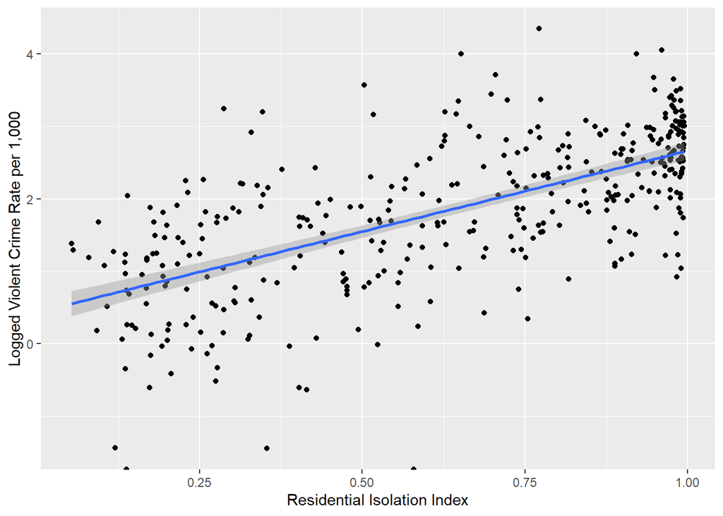

```r
scatterRIV <- ggplot(data = phillyWide, aes(x=residential_isolation, y=ln_viol_cr)) + geom_point() + geom_smooth(method=lm) + labs(x="Residential Isolation Index", y="Logged Violent Crime Rate per 1,000")
scatterRIV
```

To confirm the slopes demonstrated in the scatterplots are true, I’m going to use linear regression. Model m1 shows that each unit increase in food stamp usage is associated with a statistically significant .04 increase in the logged violent crime rate.

```r
phillyWide[sapply(phillyWide, is.infinite)]<-NA #Inf values on logged violent crime rate would prevent linear model from running
summary(m1 <-lm(ln_viol_cr ~ food_stamp_usage, data=phillyWide))
```

```
##
## Call:
## lm(formula = ln_viol_cr ~ food_stamp_usage, data = phillyWide)
##
## Residuals:
##     Min      1Q  Median      3Q     Max
## -3.6531 -0.4620  0.0226  0.4681  2.7129
##
## Coefficients:
##                  Estimate Std. Error t value Pr(>|t|)
## (Intercept)       0.79492    0.06987   11.38   <2e-16 ***
## food_stamp_usage  0.04010    0.00221   18.14   <2e-16 ***
## ---
## Signif. codes:  0 '***' 0.001 '**' 0.01 '*' 0.05 '.' 0.1 ' ' 1
##
## Residual standard error: 0.7355 on 368 degrees of freedom
##   (2 observations deleted due to missingness)
## Multiple R-squared:  0.4722, Adjusted R-squared:  0.4708
## F-statistic: 329.3 on 1 and 368 DF,  p-value: < 2.2e-16
```

Marginal estimates are often more translatable and useful when explaining model effects. Below we see that when food stamp usage is at 20% we can expect the logged violent crime rate to be about 1.60. Additional estimates are shown for food stamp usage at 40% and 80%.

```r
foodstamp <- data.frame(food_stamp_usage = c(20, 40, 80))
predict(m1, foodstamp)
```

```
##        1        2        3
## 1.597008 2.399094 4.003267
```

In linear regression model m2 I add in the effect of residential isolation. The effect of food stamp usage remains positive and significant. And each unit increase in the isolation index is associated with a statistically significant 1.25 increase in the logged violent crime rate.

```r
summary(m2 <-lm(ln_viol_cr ~ food_stamp_usage + residential_isolation, data=phillyWide))
```

```
##
## Call:
## lm(formula = ln_viol_cr ~ food_stamp_usage + residential_isolation,
##     data = phillyWide)
##
## Residuals:
##     Min      1Q  Median      3Q     Max
## -3.1765 -0.4055 -0.0046  0.4186  2.5017
##
## Coefficients:
##                       Estimate Std. Error t value Pr(>|t|)
## (Intercept)           0.358914   0.083587   4.294 2.25e-05 ***
## food_stamp_usage      0.026411   0.002636  10.018  < 2e-16 ***
## residential_isolation 1.251262   0.153093   8.173 4.93e-15 ***
## ---
## Signif. codes:  0 '***' 0.001 '**' 0.01 '*' 0.05 '.' 0.1 ' ' 1
##
## Residual standard error: 0.6774 on 367 degrees of freedom
##   (2 observations deleted due to missingness)
## Multiple R-squared:  0.5535, Adjusted R-squared:  0.5511
## F-statistic: 227.5 on 2 and 367 DF,  p-value: < 2.2e-16
```

But as noted earlier, I suspect that the relationship between food stamp usage and neighborhood violence to vary across levels of residential isolation. In model m3 I use an interaction effect to predict logged violence. According to model estimates, each unit increase in food stamp usage amplifies the effect of residential isolation on logged violence by 0.02.

```r
summary(m3 <-lm(ln_viol_cr ~ food_stamp_usage*residential_isolation, data=phillyWide))
```

```
##
## Call:
## lm(formula = ln_viol_cr ~ food_stamp_usage * residential_isolation,
##     data = phillyWide)
##
## Residuals:
##      Min       1Q   Median       3Q      Max
## -3.01220 -0.43451 -0.02108  0.43276  2.55371
##
## Coefficients:
##                                        Estimate Std. Error t value Pr(>|t|)
## (Intercept)                            0.577496   0.133444   4.328 1.95e-05 ***
## food_stamp_usage                       0.012431   0.007170   1.734 0.083820 .
## residential_isolation                  0.852324   0.243884   3.495 0.000533 ***
## food_stamp_usage:residential_isolation 0.020135   0.009611   2.095 0.036845 *
## ---
## Signif. codes:  0 '***' 0.001 '**' 0.01 '*' 0.05 '.' 0.1 ' ' 1
##
## Residual standard error: 0.6743 on 366 degrees of freedom
##   (2 observations deleted due to missingness)
## Multiple R-squared:  0.5588, Adjusted R-squared:  0.5552
## F-statistic: 154.5 on 3 and 366 DF,  p-value: < 2.2e-16
```

```r
library(sjPlot)
marginsViol <- plot_model(m3, type="int", mdrt.values = "meansd", axis.title=c("% Households Reporting Food Stamp Usage","Logged Violent Crime Rate per 1,000"), title="Predictive Margins of Violent Crime in Philadelphia Tracts", legend.title="Residential Isolation")
```

[output not shown]

# Conclusion

# References

Peterson, R. D., & Krivo, L. J. (2010). *Divergent Social Worlds: Neighborhood Crime and the Racial-Spatial Divide.* Sage.